# Relationship between Migration, Distance, Education, Medicine, and GDP

2655626

word count:2079

```r
pkgs <- c("tidyverse","geojsonio","SpatialPosition","stargazer","rprojroot","kableExtra","sf","caret","geosphere", "proxy","terra","parallelly","timechange","gridExtra","factoextra","car")
installed <- installed.packages()[,1]
install <- pkgs[!(pkgs %in% installed)]
if(length(install)) install.packages(install, dependencies = TRUE)
invisible(lapply(pkgs, require, character.only = TRUE))
```

```r
library(tidyverse)
library(geojsonio)
library(SpatialPosition)
library(stargazer)
library(rprojroot)
library(kableExtra)
library(sf)
library(caret)
library(factoextra)
library(car)
```

Introduction

In China, the migration is always an important index to tell the change of society. In order to better understand the reason why residents choose to move from their birth places to their living places, I decided to take advantage of the Gravity model to find out the relationship between migration and other important factors, including distance, per capita GDP, higher education level and medicine level. Since the model distinguish the original place and the destination, I select the per capita GDP as the “pull attraction” and both medicine and education as “push attraction”. I hope to combine these attractive factors with distance, by the Gravity model, and see how great an influence they have on the amount of migration. For example, an area with a high level’s education and medicine seems like an attractive place for people to move to, but going to a better university or curing an illness does not mean people have to live there. Therefore, by analyzing the seventh National Population Census of China, I want to find out the key factors which influencing the migration between provinces most. Although I have to admit that my research cannot be very comprehensive, it still can not only help me better understand the mechanism of migration flow, but also suggest some advice for the policies.

Data Preprocessing

The migration data is from the seventh National Population Census which happened in 2020. (Xue Xin-Xin and Xin Li-Guo, 2024) The code below shows I read the migration data into RStudio. Before that, I already translated the name of the provinces into English in the Excel. After reading, I convert the wide table to a long table using the “pivot_longer” function to make it become the pair of the original places and the destinations. Meanwhile, I rename the column and filter out the NA data.

```r
data<-read.csv("qianhu.csv")
#colnames(data)
data2 <- data %>%
  pivot_longer(
    cols = -Place_of_Residence,
    names_to = "Destination",
    values_to = "Population"
  )
data2 <- data2 %>%
  filter(complete.cases(.))
```

As I need the distance between each province and the data did not include it, I need to add it by myself. However, the provinces are too big to locate coordinates, I decided to choose the coordinates of each province’s capital city to represent the provinces. I did this for reasons. The capital cities are usually the biggest cities, so they are great and attractive places for immigrants. Although in some provinces there are some other cities that have similar status, it is very common that the capital is the most important and popular. Therefore, I search each capital’s latitude and longitude coordinate online and add them to the data frame, checking if anything is wrong and calculating the distance.

```r
locations <- data.frame(
  Province = c(
    "Beijing", "Tianjin", "Hebei", "Shanxi", "NeimengGu", "Liaoning",
    "Jilin", "HeilongJiang", "Shanghai", "Jiangsu", "Zhejiang", "Anhui",
    "Fujian", "Jiangxi", "Shandong", "Henan", "Hubei", "Hunan", "Guangdong",
    "Guangxi", "Hainan", "Chongqing", "Sichuan", "Guizhou", "Yunnan",
    "Tibet", "Shaanxi", "Gansu", "Qinghai", "Ningxia", "Xinjiang","Xizang"
  ),
  Latitude = c(
    39.9042, 39.3434, 38.0428, 37.8706, 40.8174, 41.8057,
    43.8868, 45.8038, 31.2304, 32.0617, 30.2875, 31.8612,
    26.0753, 28.6829, 36.6758, 34.7466, 30.5928, 28.2278, 23.1291,
    22.8170, 20.0442, 29.5630, 30.5723, 26.5783, 25.0453,
    29.6520, 34.2658, 36.0611, 36.6173, 38.4872, 43.8256, 29.6520
  ),
  Longitude = c(
    116.4074, 117.3616, 114.5149, 112.5489, 111.7652, 123.4315,
    125.3245, 126.5350, 121.4737, 118.7969, 120.1536, 117.2856,
    119.3062, 115.8582, 117.0009, 113.6254, 114.3054, 112.9389, 113.2644,
    108.3661, 110.1999, 106.5516, 104.0665, 106.7135, 102.7100,
    91.1175, 108.9398, 103.8236, 101.7782, 106.2309, 87.6168, 91.1175
  )
)

data2 <- data2 %>%
  left_join(locations, by = c("Place_of_Residence" = "Province")) %>%
  rename(Source_Lat = Latitude, Source_Lon = Longitude) %>%
  left_join(locations, by = c("Destination" = "Province")) %>%
  rename(Dest_Lat = Latitude, Dest_Lon = Longitude)

if (any(is.na(data2$Source_Lat)) | any(is.na(data2$Dest_Lat))) {
  stop("xxx")
}

data2 <- data2 %>%
  rowwise() %>%
  mutate(
    Distance_m = distHaversine(
      c(Source_Lon, Source_Lat),
      c(Dest_Lon, Dest_Lat)
    )
  ) %>%
  ungroup()

data.z <- data2 %>%
  select(Place_of_Residence, Destination, Population, Distance_m)
data.z<-rename(data.z,'migration'='Population')
head(data.z)
```

```
## # A tibble: 6 × 4
##   Place_of_Residence Destination migration Distance_m
##   <chr>              <chr>           <int>      <dbl>
## 1 Beijing            Tianjin         19025    102912.
## 2 Beijing            Hebei          234975    264109.
## 3 Beijing            Shanxi          56599    403703.
## 4 Beijing            NeimengGu       34701    406621.
## 5 Beijing            Liaoning        48935    627925.
## 6 Beijing            Jilin           35064    860969.
```

After that, I plan to gain data about GDP, education and medicine. As I mentioned above, the seventh National Population Census happened in 2020, and the sixth census was in 2010. In that case, I decided to gain the data I want during the decade. I choose “the number of students enrolled in undergraduate universities” to represent the higher education level of a province, and “the number health care workers per 100,000 people” to represent the medicine level. AS for the per capita GDP, I can only gain the GDP data, so I calculate it by dividing by population. All the data are available in the National Bureau of Statistics of China. As a result, I calculate the average number of these three variables and plot the relationship between each of them and the migration into one picture.

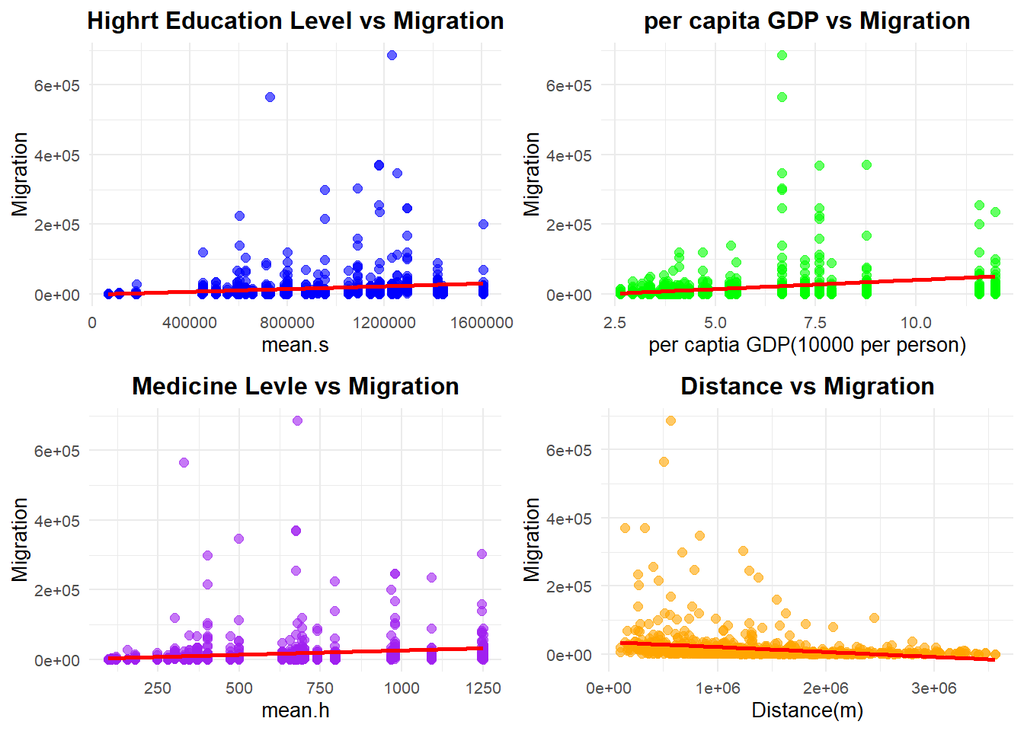

```r
school<-read.csv("school.csv")
school$mean.s <- round(apply(school[, -1], 1, mean)*10000)
gdp<-read.csv("GDP.csv")
gdp$mean.g<-apply(gdp[, -1], 1, mean)
hospital<-read.csv("hospital.csv")
hospital$mean.h<- round(apply(hospital[, -1], 1, mean))
population<-read.csv("population.csv")
population$mean.p<- round(apply(population[, -1], 1, mean))

data.z <- data.z %>%
  left_join(school%>% select(Location,mean.s), by = c('Destination' = 'Location')) %>%
  left_join(gdp%>% select(Location,mean.g), by = c('Place_of_Residence' = 'Location')) %>%
  left_join(hospital%>% select(Location,mean.h), by = c('Destination' = 'Location')) %>%
  left_join(population%>% select(Location,mean.p), by = c('Place_of_Residence' = 'Location'))

pm.s <- ggplot(data.z, aes(x = mean.s, y = migration)) +
  geom_point(color = "blue", size = 2, alpha = 0.6) +
  geom_smooth(method = lm, color = "red", se = FALSE) +
  labs(title = "Highrt Education Level vs Migration",
       x = "mean.s",
       y = "Migration") +  # 添加标题和轴标签
  theme_minimal(base_size = 10) +  # 使用简洁主题
  theme(plot.title = element_text(hjust = 0.5, face = "bold"))  # 标题居中加粗

# 图形 2: mean.g/mean.p vs migration
pm.g <- ggplot(data.z, aes(x = mean.g / mean.p, y = migration)) +
  geom_point(color = "green", size = 2, alpha = 0.6) +
  geom_smooth(method = lm, color = "red", se = FALSE) +
  labs(title = "per capita GDP vs Migration",
       x = "per captia GDP(10000 per person)",
       y = "Migration") +
  theme_minimal(base_size = 10) +
  theme(plot.title = element_text(hjust = 0.5, face = "bold"))

# 图形 3: mean.h vs migration
pm.h <- ggplot(data.z, aes(x = mean.h, y = migration)) +
  geom_point(color = "purple", size = 2, alpha = 0.6) +
  geom_smooth(method = lm, color = "red", se = FALSE) +
  labs(title = "Medicine Levle vs Migration",
       x = "mean.h",
       y = "Migration") +
  theme_minimal(base_size = 10) +
  theme(plot.title = element_text(hjust = 0.5, face = "bold"))

# 图形 4: Distance_m vs migration
pm.p <- ggplot(data.z, aes(x = Distance_m, y = migration)) +
  geom_point(color = "orange", size = 2, alpha = 0.6) +
  geom_smooth(method = lm, color = "red", se = FALSE) +
  labs(title = "Distance vs Migration",
       x = "Distance(m)",
       y = "Migration") +
  theme_minimal(base_size = 10) +
  theme(plot.title = element_text(hjust = 0.5, face = "bold"))

# 将四个图排列在一起
grid.arrange(pm.s, pm.g, pm.h, pm.p, ncol = 2)
```

These four plots show the relationship between each variable and the migration. The “mean.s” is the average number of students enrolled in undergraduate universities, “mean.h” is the average number of health care workers per 100,000 people, and the “mean.g/mean.p” is the per capita GDP (ten thousand yuan per person) and the “Distance_m” means take meter as unit. Obviously, the positive correlation can be found between migration and the capita GDP. On the other hand, distance is negatively correlated with migration. For the education and medicine, the plot shows a slight positive correlation. After a brief understanding of these relationships, I use the OLS and Poisson regression to build my models.

Model building

|  | *Dependent variable:* |  |
| --- | --- | --- |
|  | log(migration) | (migration) |
|  | *OLS* | *Poisson* |
|  | (1) | (2) |
| log(Distance_m) | -1.088*** | -0.813*** |
|  | (0.056) | (0.0004) |
| log(mean.h) | 1.059*** | 0.736*** |
|  | (0.086) | (0.001) |
| log(mean.g/mean.p) | 1.612*** | 1.542*** |
|  | (0.089) | (0.001) |
| log(mean.s) | 0.135* | 0.219*** |
|  | (0.081) | (0.001) |
| Constant | 12.642*** | 10.536*** |
|  | (1.221) | (0.012) |
| Observations | 930 | 930 |
| R<sup>2</sup> | 0.637 |  |
| Adjusted R<sup>2</sup> | 0.636 |  |
| Log Likelihood |  | -10,743,418.000 |
| Akaike Inf. Crit. |  | 21,486,847.000 |
| Residual Std. Error | 1.007 (df = 925) |  |
| F Statistic | 406.174*** (df = 4; 925) |  |
| *Note:* | p<0.1; p<0.05; p<0.01 |  |

From the results of the two models, most of the differences are rather small, except the “mean.s”, which represents the higher education level. In the OLS model, it is not as statistically and significantly positive as that in the Poisson regression. In fact, it is not statistically significant at 95% confidence intervals in OLS model, while the p-value is less than 0.1 but more than 0.05.

Let’s start with the other results. There is no doubt that the distance, per capita GDP and the medicine level are statistically and significantly correlated with migration, as the distance shows a negative relationship and both per capita GDP and the medicine level show a positive relationship. These results are suggesting that a place with higher per capita GDP and the medicine level is more attractive to the immigrants, because it means that there are higher income, more job opportunities and higher life expectancy. The distance becomes a resistance, as it will take more time and money to get farther away.

As for the difference between the two models, I decided to compare the two models to find out which one is better. Residual distribution is a good way to do it. It can ensure that there is no systematic error in the model and that the residual distribution is random and normal.

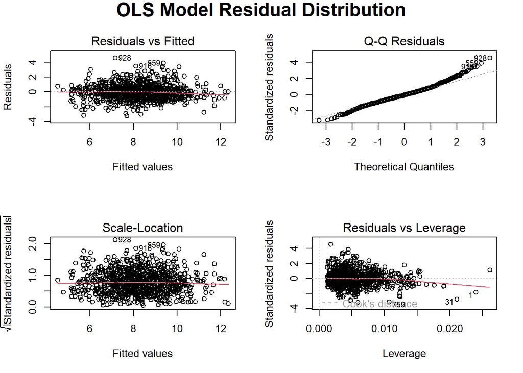

```r
par(mfrow = c(2, 2))
plot(ols.model)
mtext("OLS Model Residual Distribution", outer = TRUE, line = -1.5, cex = 1.5, font = 2)
```

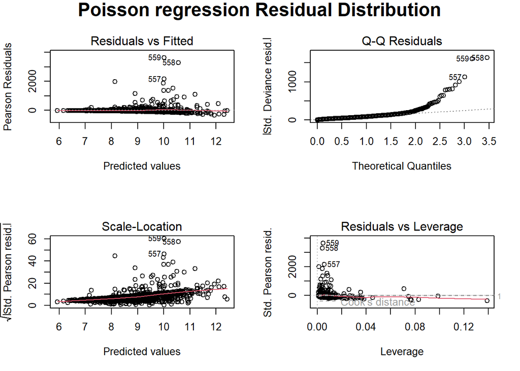

```r
par(mfrow = c(2, 2))
plot(glm.model)
mtext("Poisson regression Residual Distribution", outer = TRUE, line = -1.5, cex = 1.5, font = 2)
```

Above is the residual distribution of two models.

Firstly, Residuals vs Fitted. In the OLS model, the residuals are randomly distributed around the zero line, and there is no obvious nonlinear pattern. However, in the Poisson regression, the residuals show an slight upward trend with an increase of the fitting value with some extreme deviation points, showing a potential nonlinear pattern. This means that the Poisson regression has a larger systematic error.

Secondly, Q-Q Plot. Compared with the OLS model where the residual points basically fall on the line of the theoretical distribution, the residual points in the Poisson regression deviate from the theoretical line seriously at the tail of the distribution. This result shows that the residuals obviously do not follow a normal distribution in the Poisson regression

Then, Scale-Location. The distribution of standardized residuals in the OLS model is uniform, but there is heteroscedasticity in the Poisson regression, which indicates that the residuals of some predicted values are too large.

Last but not least, Residuals vs Leverage. There are some particularly high residual points in the Poisson regression, and the residuals are not evenly distributed, indicating that the model is greatly affected by these extreme values. The OLS model does not have these problems.

Because of this result, I prefer to believe the OLS model rather than the Poisson regression. In that case, the higher education level would not have a statistical correlation with the migration. This is different from the plot before, and it is because the model includes other variables which will affect the higher education level’s correlation with the migration. As they are not related, it means that during the decade, many families did not move away with their children’s education, also there were quite a few students in the undergraduate universities who did not choose to find a job locally and move on.

PCA

```r
summary(ols.model)
```

```
##
## Call:
## lm(formula = log(migration) ~ log(Distance_m) + log(mean.h) +
##     log(mean.g/mean.p) + log(mean.s), data = data.z)
##
## Residuals:
##     Min      1Q  Median      3Q     Max
## -3.2042 -0.6026 -0.0518  0.5621  4.5461
##
## Coefficients:
##                    Estimate Std. Error t value Pr(>|t|)
## (Intercept)        12.64170    1.22106   10.35   <2e-16 ***
## log(Distance_m)    -1.08834    0.05633  -19.32   <2e-16 ***
## log(mean.h)         1.05883    0.08583   12.34   <2e-16 ***
## log(mean.g/mean.p)  1.61229    0.08855   18.21   <2e-16 ***
## log(mean.s)         0.13524    0.08147    1.66   0.0973 .
## ---
## Signif. codes:  0 '***' 0.001 '**' 0.01 '*' 0.05 '.' 0.1 ' ' 1
##
## Residual standard error: 1.007 on 925 degrees of freedom
## Multiple R-squared:  0.6372, Adjusted R-squared:  0.6356
## F-statistic: 406.2 on 4 and 925 DF,  p-value: < 2.2e-16
```

Based on the OLS model, I want to figure out which variable is more “significantly correlated” with the migration. Although the t-value shows that the distance is the most influential variable (Absolute value 19.32), per capita GDP is the second (18.21), third is medicine (12.34) and education the least important (1.66), I want to figure out how significant the difference between these figures is. The PCA can be an acceptable method (Jolliffe, 2002). It is a way to combine the original variables into a new set of variables by linear transformation. Additionally, it can reduce the complexity of data by declining the number of variables. As my data has four variables with varying degrees of influence, I want the PCA to help me combine them and visualize the differences between the figures.

```r
pca_data <- data.z %>%
  select(Distance_m)
pca_data$G.P <-data.z$mean.g/data.z$mean.p
pca_data$medicine <-data.z$mean.h
pca_data$education <-data.z$mean.s
pca_data <- scale(pca_data)
pca <- prcomp(pca_data, center = TRUE, scale. = TRUE)
print(pca$rotation)
```

```
##                    PC1        PC2         PC3         PC4
## Distance_m  0.30924702  0.5490337 -0.76575922  0.12861210
## G.P        -0.04214221 -0.8060887 -0.58934067  0.03350528
## medicine   -0.65963455  0.1868918 -0.24738241 -0.68465734
## education  -0.68371966  0.1177049 -0.07136061  0.71664542
```

After that, I built a new OLS model using the migration and the PCA variables. Since I need to use logarithmic transformations, I translate the PCA variables as a whole forward to ensure that there are no zeros and negative values.

```r
pca_scores <- as.data.frame(pca$x[,1:4])
pca_test <- data.z %>%
  select(migration) %>%
  bind_cols(pca_scores)
pca_test <- pca_test %>%
  mutate(
    PC1 = PC1 + abs(min(PC1, na.rm = TRUE)) + 1,
    PC2 = PC2 + abs(min(PC2, na.rm = TRUE)) + 1,
    PC3 = PC3 + abs(min(PC3, na.rm = TRUE)) + 1,
    PC4 = PC4 + abs(min(PC4, na.rm = TRUE)) + 1
  )
pca_model <- lm(log(migration) ~ log(PC1) + log(PC2) + log(PC3) +log(PC4), data = pca_test)
summary(pca_model)
```

```
##
## Call:
## lm(formula = log(migration) ~ log(PC1) + log(PC2) + log(PC3) +
##     log(PC4), data = pca_test)
##
## Residuals:
##     Min      1Q  Median      3Q     Max
## -3.6951 -0.7927 -0.0375  0.6533  4.5099
##
## Coefficients:
##             Estimate Std. Error t value Pr(>|t|)
## (Intercept) 15.25541    0.36917  41.324  < 2e-16 ***
## log(PC1)    -2.38100    0.09998 -23.814  < 2e-16 ***
## log(PC2)    -2.60856    0.14578 -17.894  < 2e-16 ***
## log(PC3)     0.23360    0.17759   1.315  0.18869
## log(PC4)    -0.44041    0.16104  -2.735  0.00636 **
## ---
## Signif. codes:  0 '***' 0.001 '**' 0.01 '*' 0.05 '.' 0.1 ' ' 1
##
## Residual standard error: 1.185 on 925 degrees of freedom
## Multiple R-squared:  0.4975, Adjusted R-squared:  0.4954
## F-statistic:   229 on 4 and 925 DF,  p-value: < 2.2e-16
```

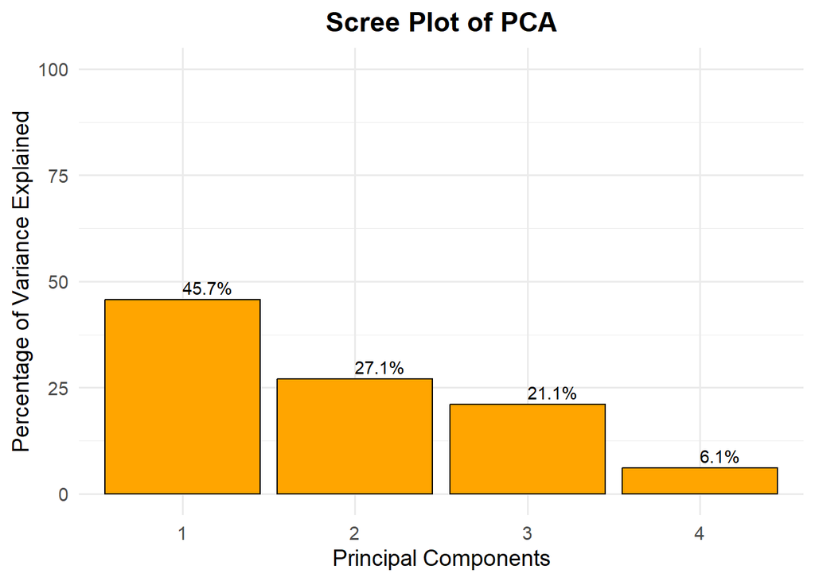

```r
fviz_eig(pca,
         geom = "bar",
         addlabels = TRUE,
         ylim = c(0, 100),
         barfill = "orange",
         barcolor = "black"
) +
  labs(title = "Scree Plot of PCA",
       x = "Principal Components",
       y = "Percentage of Variance Explained") +
  theme_minimal(base_size = 14) +
  theme(plot.title = element_text(hjust = 0.5, face = "bold"))
```

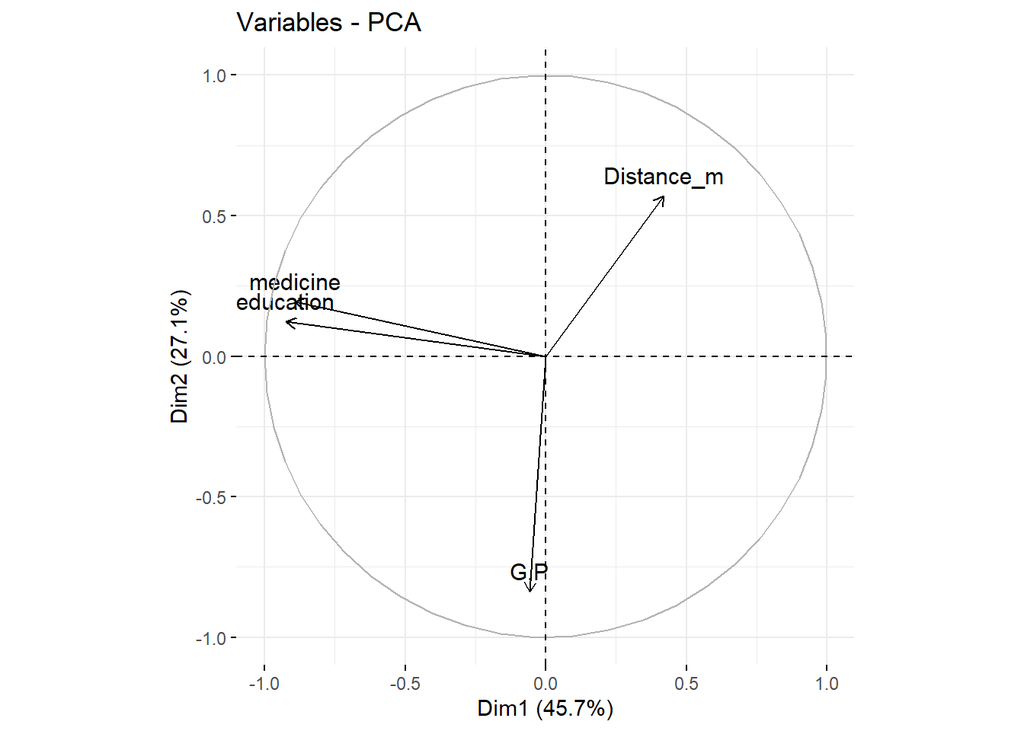

```r
factoextra::fviz_pca_var(pca, col.var = 'black')
```

By building the OLS model, it is surprising to notice that PC1, PC2 and PC4 have statistically significant and negative correlation with the migration, and PC3 have no statistical correlation with migration. Although I do not know what happened in the PCA process, the PC3 somehow means that the negative effect and positive effect come to a balance under the position of the four variables.

From the scree plot of PCA, we can see how much original variables each PCA interprets. As the plot shows, it is obvious that the PC4 only interprets a small part of the data (only 6.1%), which means it would be acceptable if we just ignore it. In fact, this is how the PCA reduce the complexity. As the original variables combined, ignoring a small part of the data would not make a big difference. Because the majority of data can still interpret the model comprehensively.

For the PC1 and PC2, as I mentioned before, the distance has a positive correlation with both of them no matter what correlation the other variables have, and there was a statistically significant negative correlation between the distance and the migration. To be specific, the function “fviz_pca_var()” output the four original variables’ effect in the PC1 and PC2. The result shows that the two PCA explained 72.8% of the variation in the data, which means they are the most important. In combination with the new OLS model, the negative effect from the distance not only overcome the positive effect from the per capita GDP in PC2, but also overcome the education and medicine in PC1. In that case, the difference between these variables’ t-values is more significant than it looks. As a result, distance is the most influential variable for immigrants.

Conclusion

In a conclusion, based on the data from the seventh National Population Census and the National Bureau of Statistics of China from 2010 to 2020, the migration between provinces is statistically significantly influenced by the distance, per capita GPD and medicine level. On the other hand, the higher education level cannot influence the immigrants to a large extend. Among these variables, distance is the most important, having a larger influence than any other variable in migration. This situation means that during the decade, immigrants in China will put the cost from the migration in the first, and with the distance further away, they may give up moving to a better but further place.

For the attractive factors, per capita GDP and medicine level are two aspects of the quality of daily life which will be paid attention by all immigrants, while higher education will only be considered by the family with around 18 years old children. It may be one reason why the higher education level is the least important. If change it into the basic education level, the education may show a higher influence. Another reason I think is that some students who are admitted into undergraduate universities will not find a local job and live there after graduation. Except those who continue education to postgraduate, although it is generally believed that local university graduates will have a higher possibility to find a local job, they may prefer better treatment no matter it is local or not, or they may choose to work locally for years and then go back to hometown. As a result, immigrants will prefer a place with higher income, higher life expectancy, better life quality and not far from hometown.

*Reference*  
[1]Xue Xin-Xin, Xin Li-Guo. (2024) ‘A study on the potential of rural labor transfer in the development of urban-rural integration: An estimation based on the data of the 7th National Population Census in Shandong Province’, Shandong Social Sciences, doi:10.14112/j.cnki.37-1053/c.2024.08.019.  
[2]Jolliffe, I.T. (2002) Principal component analysis. 2nd ed. New York: Springer.

2655626